# exercise-09

Sam Smith

3/31/2022

First, load in the dataset and do some exploratory analyses. Generate the five number summary, mean, and standard deviation for each quantitative variable.

```r
library(tidyverse)
library(dplyr)
library(skimr)
f <- "https://raw.githubusercontent.com/difiore/ada-2022-datasets/main/Street_et_al_2017.csv"
d <- read_csv(f, col_names = TRUE)
skim(d)
```

Data summary

| Name | d |
| --- | --- |
| Number of rows | 301 |
| Number of columns | 13 |
| _______________________ |  |
| Column type frequency: |  |
| character | 2 |
| numeric | 11 |
| ________________________ |  |
| Group variables | None |

**Variable type: character**

| skim_variable | n_missing | complete_rate | min | max | empty | n_unique | whitespace |
| --- | --- | --- | --- | --- | --- | --- | --- |
| Species | 0 | 1 | 10 | 41 | 0 | 301 | 0 |
| Taxonomic_group | 0 | 1 | 10 | 15 | 0 | 4 | 0 |

**Variable type: numeric**

| skim_variable | n_missing | complete_rate | mean | sd | p0 | p25 | p50 | p75 | p100 | hist |
| --- | --- | --- | --- | --- | --- | --- | --- | --- | --- | --- |
| Social_learning | 98 | 0.67 | 2.30 | 16.51 | 0.00 | 0.00 | 0.00 | 0.00 | 214.00 | ▇▁▁▁▁ |
| Research_effort | 115 | 0.62 | 38.76 | 80.59 | 1.00 | 6.00 | 16.00 | 37.75 | 755.00 | ▇▁▁▁▁ |
| ECV | 117 | 0.61 | 68.49 | 82.84 | 1.63 | 11.82 | 58.55 | 86.20 | 491.27 | ▇▁▁▁▁ |
| Group_size | 114 | 0.62 | 13.26 | 15.20 | 1.00 | 3.12 | 7.50 | 18.23 | 91.20 | ▇▂▁▁▁ |
| Gestation | 161 | 0.47 | 164.50 | 38.00 | 59.99 | 138.35 | 166.03 | 183.26 | 274.78 | ▁▅▇▃▁ |
| Weaning | 185 | 0.39 | 311.09 | 253.08 | 40.00 | 121.66 | 234.16 | 388.78 | 1260.81 | ▇▃▁▁▁ |
| Longevity | 181 | 0.40 | 331.97 | 165.67 | 103.00 | 216.00 | 301.20 | 393.30 | 1470.00 | ▇▂▁▁▁ |
| Sex_maturity | 194 | 0.36 | 1480.23 | 999.23 | 283.18 | 701.52 | 1427.17 | 1894.11 | 5582.93 | ▇▆▂▁▁ |
| Body_mass | 63 | 0.79 | 6795.18 | 14229.83 | 31.23 | 739.44 | 3553.50 | 7465.00 | 130000.00 | ▇▁▁▁▁ |
| Maternal_investment | 197 | 0.35 | 478.64 | 292.07 | 99.99 | 255.88 | 401.35 | 592.22 | 1492.30 | ▇▅▂▁▁ |
| Repro_lifespan | 206 | 0.32 | 9064.97 | 4601.57 | 2512.16 | 6126.22 | 8325.89 | 10716.60 | 39129.57 | ▇▃▁▁▁ |

Plot brain size (ECV) as a function of social group size (Group_size), longevity (Longevity), juvenile period length (Weaning), and reproductive lifespan (Repro_lifespan).

```r
library(ggplot2)
library(patchwork)
names(d)
```

```
##  [1] "Species"             "Taxonomic_group"     "Social_learning"
##  [4] "Research_effort"     "ECV"                 "Group_size"
##  [7] "Gestation"           "Weaning"             "Longevity"
## [10] "Sex_maturity"        "Body_mass"           "Maternal_investment"
## [13] "Repro_lifespan"
```

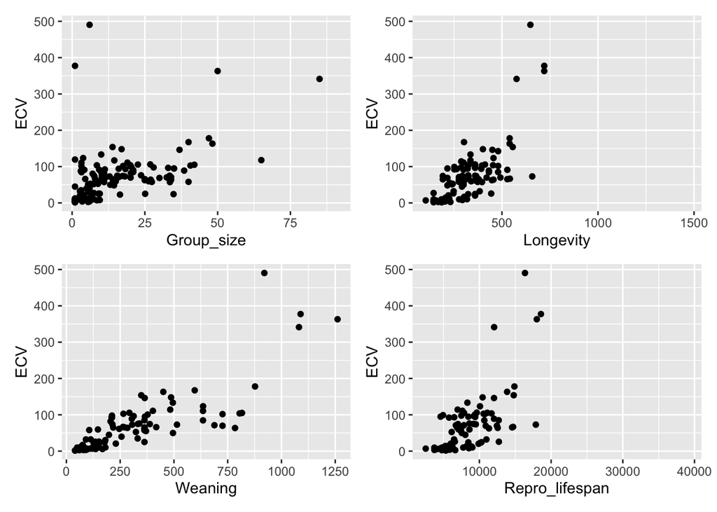

```r
p1 <- ggplot(data=d,aes(x=Group_size,y=ECV)) + geom_point(na.rm=TRUE)
p2 <- ggplot(data=d,aes(x=Longevity,y=ECV)) + geom_point(na.rm=TRUE)
p3 <- ggplot(data=d,aes(x=Weaning,y=ECV)) + geom_point(na.rm=TRUE)
p4 <- ggplot(data=d,aes(x=Repro_lifespan,y=ECV)) + geom_point(na.rm=TRUE)
p1 + p2 + p3 + p4
```

Derive the ordinary least squares regression coefficients by hand (B1 and B0) for ECV as a function of social group size. Confirm that the results are the same when you use the lm function.

```r
# first we have to remove any rows of data where ECV or Group_size values are NA.
d_narm <- d %>% filter(!is.na(ECV)) %>% filter(!is.na(Group_size))

(b1 <- cor(d_narm$ECV,d_narm$Group_size)*sd(d_narm$ECV)/sd(d_narm$Group_size))
```

```
## [1] 2.463071
```

```r
(b0 <- mean(d_narm$ECV) - b1*mean(d_narm$Group_size))
```

```
## [1] 30.35652
```

```r
model <- lm(ECV ~ Group_size,data=d)
summary(model)
```

```
##
## Call:
## lm(formula = ECV ~ Group_size, data = d)
##
## Residuals:
##    Min     1Q Median     3Q    Max
## -92.05 -29.25 -15.14  13.07 445.28
##
## Coefficients:
##             Estimate Std. Error t value Pr(>|t|)
## (Intercept)  30.3565     6.7963   4.467 1.56e-05 ***
## Group_size    2.4631     0.3508   7.021 7.26e-11 ***
## ---
## Signif. codes:  0 '***' 0.001 '**' 0.01 '*' 0.05 '.' 0.1 ' ' 1
##
## Residual standard error: 60.31 on 149 degrees of freedom
##   (150 observations deleted due to missingness)
## Multiple R-squared:  0.2486, Adjusted R-squared:  0.2436
## F-statistic:  49.3 on 1 and 149 DF,  p-value: 7.259e-11
```

Yes the values are the same!

Repeat the analysis above for three different major radiations of primates – “catarrhines”, “platyrrhines”, and “strepsirhines”) separately.

```r
# new data sets, one for each clade
cat_data <- d_narm %>% filter(Taxonomic_group == "Catarrhini")
plat_data <- d_narm %>% filter(Taxonomic_group == "Platyrrhini")
strep_data <- d_narm %>% filter(Taxonomic_group == "Strepsirhini")

# calculate OLS regression coefficients by hand
# Catarrhines
(b1_cat <- cor(cat_data$ECV,cat_data$Group_size)*sd(cat_data$ECV)/sd(cat_data$Group_size))
```

```
## [1] 1.265551
```

```r
(b0_cat <- mean(cat_data$ECV) - b1_cat*mean(cat_data$Group_size))
```

```
## [1] 81.64085
```

```r
model_cat <- lm(ECV ~ Group_size,data=cat_data)
summary(model_cat)
```

```
##
## Call:
## lm(formula = ECV ~ Group_size, data = cat_data)
##
## Residuals:
##    Min     1Q Median     3Q    Max
## -74.24 -32.18 -17.76   4.20 401.18
##
## Coefficients:
##             Estimate Std. Error t value Pr(>|t|)
## (Intercept)  81.6408    15.3317   5.325 1.27e-06 ***
## Group_size    1.2656     0.6192   2.044   0.0449 *
## ---
## Signif. codes:  0 '***' 0.001 '**' 0.01 '*' 0.05 '.' 0.1 ' ' 1
##
## Residual standard error: 76.4 on 67 degrees of freedom
## Multiple R-squared:  0.05869,    Adjusted R-squared:  0.04464
## F-statistic: 4.177 on 1 and 67 DF,  p-value: 0.0449
```

```r
# Platyrrhines
(b1_plat <- cor(plat_data$ECV,plat_data$Group_size)*sd(plat_data$ECV)/sd(plat_data$Group_size))
```

```
## [1] 1.965176
```

```r
(b0_plat <- mean(plat_data$ECV) - b1_plat*mean(plat_data$Group_size))
```

```
## [1] 16.18121
```

```r
model_plat <- lm(ECV ~ Group_size,data=plat_data)
summary(model_plat)
```

```
##
## Call:
## lm(formula = ECV ~ Group_size, data = plat_data)
##
## Residuals:
##     Min      1Q  Median      3Q     Max
## -60.528 -19.817  -3.568  19.968  72.344
##
## Coefficients:
##             Estimate Std. Error t value Pr(>|t|)
## (Intercept)  16.1812     7.3865   2.191 0.035646 *
## Group_size    1.9652     0.4554   4.315 0.000136 ***
## ---
## Signif. codes:  0 '***' 0.001 '**' 0.01 '*' 0.05 '.' 0.1 ' ' 1
##
## Residual standard error: 26.98 on 33 degrees of freedom
## Multiple R-squared:  0.3607, Adjusted R-squared:  0.3414
## F-statistic: 18.62 on 1 and 33 DF,  p-value: 0.0001364
```

```r
#Strepsirhines
(b1_strep <- cor(strep_data$ECV,strep_data$Group_size)*sd(strep_data$ECV)/sd(strep_data$Group_size))
```

```
## [1] 1.840664
```

```r
(b0_strep <- mean(strep_data$ECV) - b1_strep*mean(strep_data$Group_size))
```

```
## [1] 8.176384
```

```r
model_strep <- lm(ECV ~ Group_size,data=strep_data)
summary(model_strep)
```

```
##
## Call:
## lm(formula = ECV ~ Group_size, data = strep_data)
##
## Residuals:
##     Min      1Q  Median      3Q     Max
## -15.650  -6.167  -2.777   1.300  34.833
##
## Coefficients:
##             Estimate Std. Error t value Pr(>|t|)
## (Intercept)   8.1764     2.1354   3.829 0.000404 ***
## Group_size    1.8407     0.4728   3.893 0.000332 ***
## ---
## Signif. codes:  0 '***' 0.001 '**' 0.01 '*' 0.05 '.' 0.1 ' ' 1
##
## Residual standard error: 10.37 on 44 degrees of freedom
## Multiple R-squared:  0.2562, Adjusted R-squared:  0.2393
## F-statistic: 15.15 on 1 and 44 DF,  p-value: 0.0003324
```

The regression coefficients differ among groups. I can see this by looking at my calculated (by hand) b1 and b0 values for each group and also by looking at the “estimate” column of the print out from the summary function of the model when I run it using lm. The b1 values are pretty similar among groups and all lower than the b1 for the whole dataset together. The b0 values are drastically different among groups and also when comparing groups to the b0 of model that included the entire dataset.

Going back to the regression that includes all the data, calculate the standard error for the slope coefficient, the 95% CI, and the p-value associated with this coefficient by hand. Also extract this same information from the results of running the lm() function.

```r
# standard error for the slope coefficient by hand
n <- nrow(d_narm)
mean_x <- mean(d_narm$Group_size)
y_pred = b0 + b1*d_narm$Group_size
y_error = d_narm$ECV - y_pred
x_error <- d_narm$Group_size-mean_x
(std_err_b1 <- sqrt((sum(y_error^2))/((n-2)*sum((d_narm$Group_size-mean_x)^2))))
```

```
## [1] 0.3508061
```

```r
# calculate the t statistic by hand
(t_stat <- b1/std_err_b1)
```

```
## [1] 7.021176
```

```r
# calculate the 95% confidence interval by hand
(ci_t <- b1 + c(-1, 1) * qt(1 - 0.05 / 2, df = n - 2) * std_err_b1)
```

```
## [1] 1.769874 3.156269
```

```r
# calculate p value by hand
p_up <- 1-pt(abs(t_stat), df=n-2)
p_low <- pt(-1*abs(t_stat ), df=n-2)
(p <- p_up + p_low)
```

```
## [1] 7.259436e-11
```

```r
# using built in function
model <- lm(ECV ~ Group_size,data=d)
CI <- confint(model, level = 1 - 0.05)
summary(model)
```

```
##
## Call:
## lm(formula = ECV ~ Group_size, data = d)
##
## Residuals:
##    Min     1Q Median     3Q    Max
## -92.05 -29.25 -15.14  13.07 445.28
##
## Coefficients:
##             Estimate Std. Error t value Pr(>|t|)
## (Intercept)  30.3565     6.7963   4.467 1.56e-05 ***
## Group_size    2.4631     0.3508   7.021 7.26e-11 ***
## ---
## Signif. codes:  0 '***' 0.001 '**' 0.01 '*' 0.05 '.' 0.1 ' ' 1
##
## Residual standard error: 60.31 on 149 degrees of freedom
##   (150 observations deleted due to missingness)
## Multiple R-squared:  0.2486, Adjusted R-squared:  0.2436
## F-statistic:  49.3 on 1 and 149 DF,  p-value: 7.259e-11
```

The values match!

Then, use a permutation approach with 1000 permutations to generate a null sampling distribution for the slope coefficient. We need to permute the association between the explanatory variable (group size) and response variable (ECV). I will do this by shuffling the Group_size variable and holding the ECV constant. I will also find the p-value associated with the original slope coefficient.

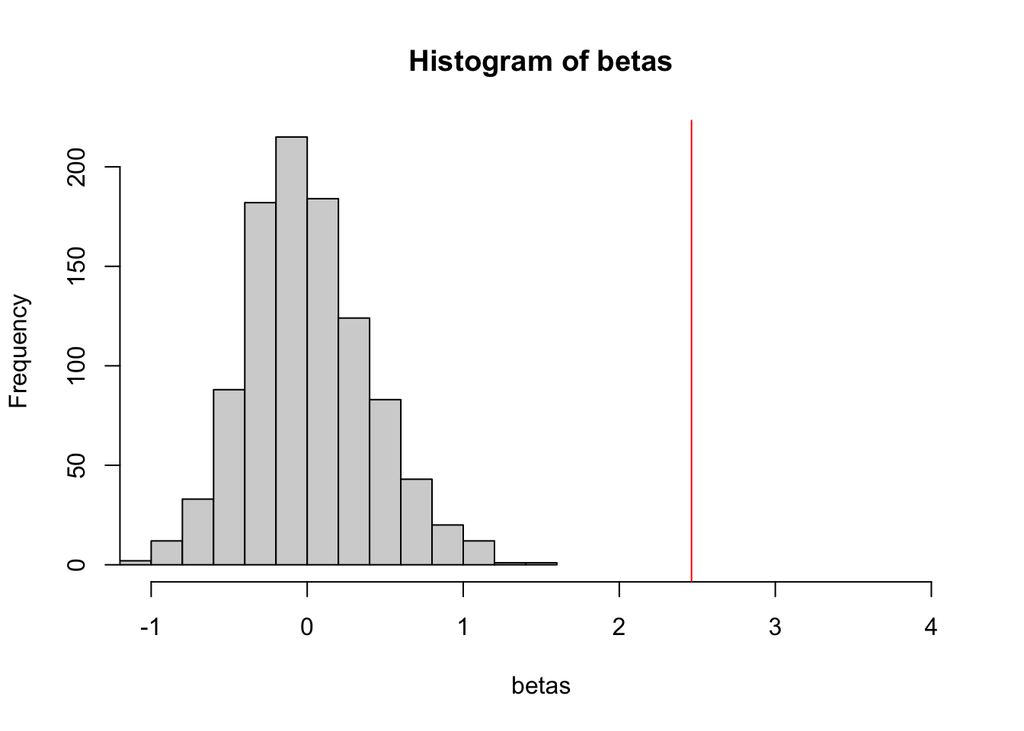

```r
perms <- 1000
betas <- c()
for(i in 1:perms){
  # shuffle group size assignments
  permuted_data <- sample(d_narm$Group_size)
  # calculate b1
  b <- cor(d_narm$ECV,permuted_data)*sd(d_narm$ECV)/sd(permuted_data)
  # assign b1 value to the vector
  betas <- append(betas,b)
  i=i+1
}

# look at the graph to see how different the calculated b1 from original data is from the sampling distribution
hist(betas,xlim=c(-1,4))
abline(v=b1,col="red")
```

```r
# find p-value associated with original b1 value
(p <- sum(abs(betas) >= abs(b1)) / perms)
```

```
## [1] 0
```

When I calculate this value, I get zero. If I increased the number of permutations, I might find a non-zero number for the p-value, but it will still be very tiny.

Finally, use bootstrapping to generate a 95% CI for your estimate of the slope coefficient using both the percentile method and the theory-based method (i.e., based on the standard deviation of the bootstrapped sampling distribution). What is the p value associated with your observed slope coefficient based on each of these methods?

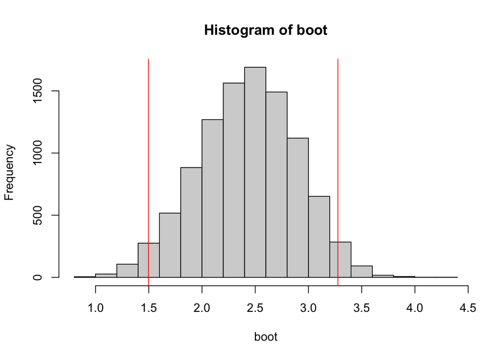

```r
num_boots <- 10000
boot <- vector(length=num_boots)
n <- length(d_narm$Group_size)
indices <-c(1:n)
for(i in 1:num_boots){
  # get row number for randomly picked observation
  index <- sample(indices,n,replace=TRUE)
  temp_data <- d_narm[index,]
  boot[[i]] <- cor(temp_data$ECV,temp_data$Group_size)*sd(temp_data$ECV)/sd(temp_data$Group_size)
} # can also use sample_n
hist(boot)
abline(v = quantile(boot, 0.025), col = "red")
abline(v = quantile(boot, 0.975), col = "red")
```

```r
# 95% CI using percentile method
(CI_percentile_lower <- quantile(boot,0.025))
```

```
##     2.5%
## 1.496962
```

```r
(CI_percentile_upper <- quantile(boot,0.975))
```

```
##    97.5%
## 3.276424
```

```r
# 95% CI using the theory-based method
(ci_normal <- mean(boot) + c(-1, 1) * qnorm(1 - 0.05 / 2) * sd(boot))
```

```
## [1] 1.527203 3.329048
```

```r
# calculating the p value
(p_boot <- pnorm(mean(betas),mean(boot),sd(boot)))
```

```
## [1] 6.808394e-08
```